# Initiation to R software Session III

Master AMSE 1st year, 2019

## Import/Export text files

## Import text files

To load text files stored in your computer, use the function `read.table()`.

`read.table(file, sep, header)`

- `file`: the name of the file (character)
- `sep`: separator used in file (" " by default)
- `header`: `TRUE` if file contains columns names, `FALSE` by default

```r
tab = read.table("../data/age_gender.txt", header = T); head(tab, 3)
```

```
##   age gender
## 1  28      F
## 2  36      H
## 3  45      F
```

## Import text files: variants of `read.table()`

- `file.choose()`: choose a file through the GUI.
- `read.csv()`: read CSV files.
- `read.delim()`: read delimited text files.
- `read.fwf()`: read fixed-width-formatted files.

R can read files in specific software formats (Excel, SAS, SPSS, Stata) using the functions from the packages `foreign`.

```r
# Try this
install.packages("foreign")
library(foreign)
?read.dta
```

## Export text files

To export a `data.frame` into text files on your working directory, use the function `write.table()`.

`write.table(x, file, append, col.names, row.names)`

- `x`: `data.frame`
- `file`: name of the file in which to write
- `append`: if `TRUE`, add to an (eventually existing) file, if `FALSE`, overwrite the existing file (default)
- `col.names` and `row.names`: if `TRUE`, write the columns/rows names

```r
write.table(tab, "age_gender.txt", row.names = T, col.names = T)
```

`write()` is the same as `write.table()` with less options.

## Save/Load R objects

R objects can be saved in both ascii and binary formats:

- `dump()`: save R objects in ascii format
- `source()`: load R objects saved with `dump()`
- `save()`: save R objects in binary format
- `load()`: load R objects saved with `save()`

```r
# Try this
dump(ls(), file = "objects.txt")
source("objects.txt")
```

## Probability distributions and sample simulation

## Probability distribution and sample simulation

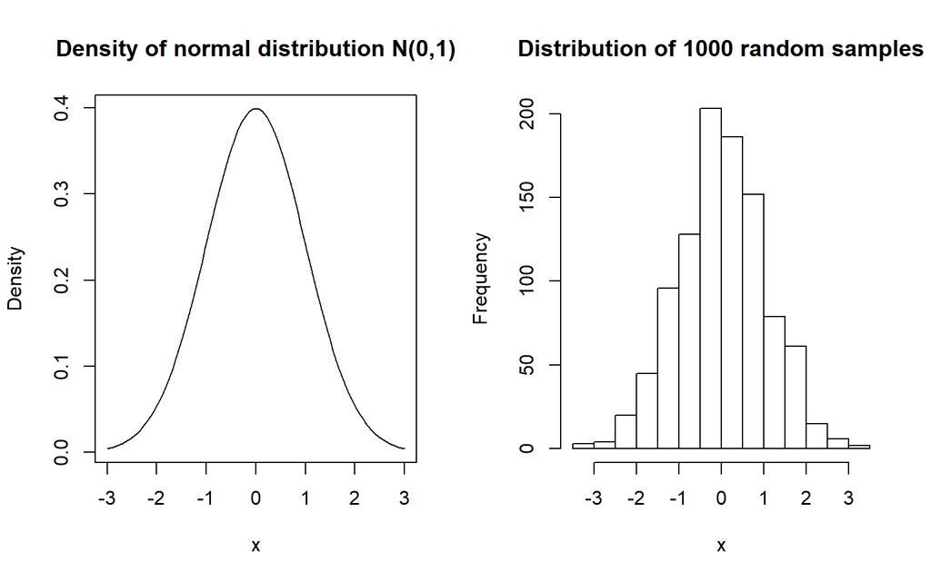

## Probability distribution and sample simulation

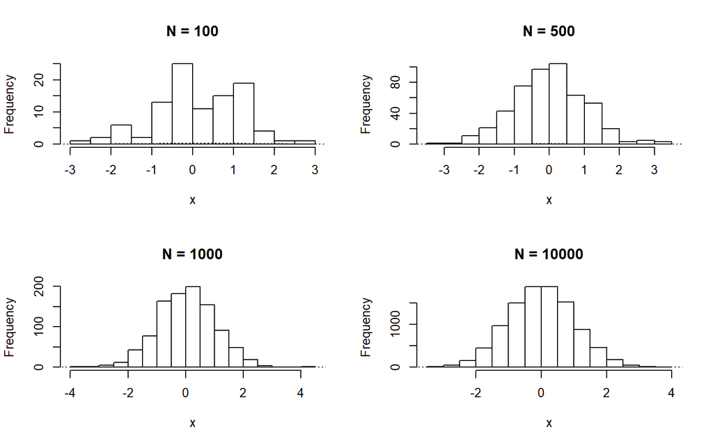

## Usual probability distributions

Distributions for **continuous** variables:

- **Normal** distribution: \(X \leadsto N(\mu, \sigma)\): \(f(x)=\frac{1}{\sigma\sqrt{2\pi}}e^{-\frac{1}{2\sigma^2}(x-\mu)^2}, \forall x\in\mathbb{R}\).
- **Uniform** distribution: \(X \leadsto U(a, b)\): if \(x\in[a,b]\), \(f(x)=\frac{1}{b-a}\), elsewhere \(f(x) = 0\).

Distributions for **discrete** variables:

- **Poisson** distribution: \(X \leadsto P(\lambda)\): \(P(X=x)=e^{-\lambda}\frac{\lambda^x}{x!}, \forall x\in\mathbb{N}\).
- **Binomial** distribution: \(X \leadsto B(n,p)\): \(P(X=x)=C_n^x p^x (1-p)^{n-x}, \forall x\in[0,n]\).

## Probability distributions in R

R can evaluate probabilistic quantitites following usual probability distributions.

Usual distributions: `*norm()`, `*binom()`, `*chisq()`, `*unif()`, `*pois()`, `*t()`, `*exp()`, …

`*` should be replaced by one of the following:

- `p` distribution function, \(F(x) = P(X<=x)\), use `pnorm()`, `pbinom()`, `pt()`, …
- `d` density \(P(X=x)\) or \(f(x)\), use `dnorm()`, `dt()`, `dpois()`, …
- `q` quantiles of order \(q\), \(\text{argmin}_x\{P(X<=x)>q\}\), use `qnorm()`, `qbinom()`, `qchisq()`, …
- `r` sample simulation, use `runif()`, `rpois()`, …

## Probability distributions examples

```r
dbinom(3, 10, 0.2)
```

```
## [1] 0.2013266
```

```r
rbinom(10, 10, 0.2)
```

```
##  [1] 1 3 1 1 1 1 3 2 3 2
```

```r
pbinom(1, 10, 0.2)
```

```
## [1] 0.3758096
```

## Probability distributions examples

```r
pbinom(2, 10, 0.2)
```

```
## [1] 0.6777995
```

```r
qbinom(0.5, 10, 0.2)
```

```
## [1] 2
```

```r
qchisq(0.1, 8)
```

```
## [1] 3.489539
```

## Probability distributions examples

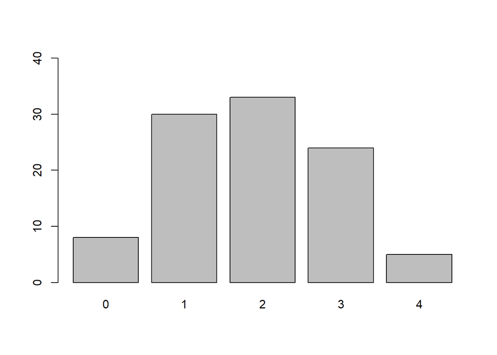

```r
x=rbinom(100, 5, 1/3)
par(mfrow = c(1,1))
barplot(table(x), ylim = c(0, 40))
```

## Probability distributions examples

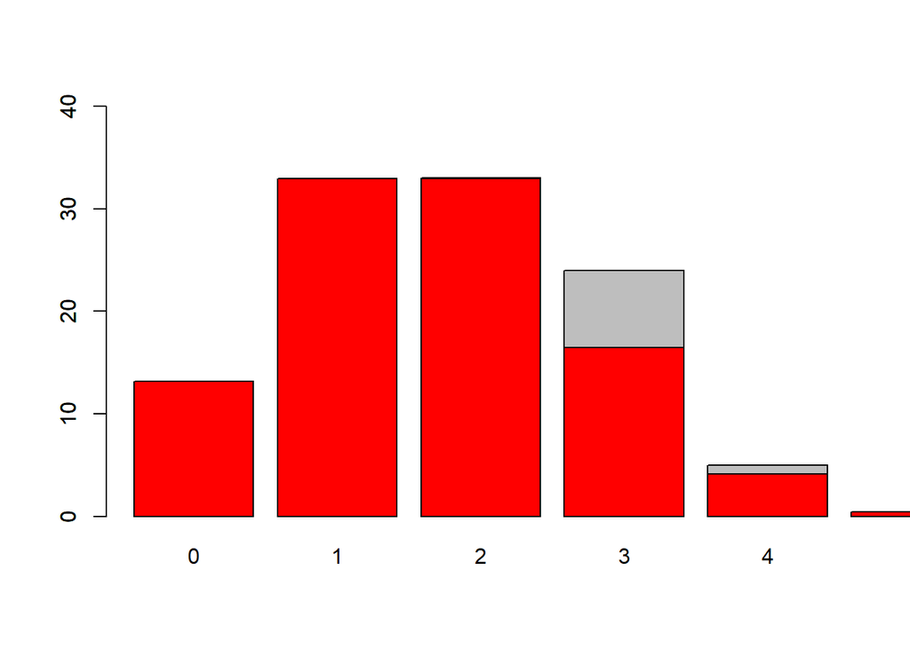

```r
# add a barplot to an existing barplot
barplot(table(x), ylim = c(0, 40))
barplot(dbinom(0:5, 5, 1/3)*100, add=T, col=2)
```

## Descriptive statistics

## Characteristics of a statistical serie

Let \((x,y)\) be a pair of statistical series (`vector` or `data.frame`).

- `table(x)` returns the value counts of \(x\) (for \(x\) discrete or character).
- `summary(x)` returns a summary of descriptives statistics of \(x\) (mninimum, 1st quartile, mean, median, 3rd quartile, maximum), for \(x\) numeric.
- `mean(x)`, `median(x)`, `var(x)`, `sd(x)` for mean, median, variance and standard-deviation (\(x\) numeric).
- `quantile(x, probs)` returns the quantiles of \(x\) (numeric) corresponding to parameter vector of probabilities (% of the population)/ Returns quartiles by default.
- `cor(x,y)`, `cov(x,y)` return the correlation/covariance matrix between \(x\) and \(y\) (numeric).

## Characteristics of a statistical serie: examples

```r
# Try this
age = c(18, 15, 12, 16, 20, 17)
weight = c(55, 57, 46, 54, 60,57)
name = c("a", "b", "c", "a")
table(weight); table(name)
summary(weight); summary(name)
mean(weight)
quantile(age)
quantile(weight)
cor(age, weight)
quantile(weight, probs = 0.25)
quantile(age, probs = c(0.1, 0.4))
```

## Visualization of a statistical serie

- `hist(x)` plot the histogram of \(x\).
- `density(x)` computes the kernel density estimator of \(x\)..
- `ecdf(x)` computes the empirical distribution function of \(x\).
- `barplot(x)` bar chart of \(x\) (discrete).
- `stem(x)` tree of values of \(x\) (discrete).
- `boxplot(x)` boxplot of values of \(x\) (discrete).
- `qqnorm(x)` plot the quantiles of \(x\) in function of the quantiles of the normal distribution.
- `qqplot(x,y)` plot the quantiles of \(x\) in function of the quantiles of \(y\).
- `plot(x)` plot the values of \(x\).
- `plot(x,y)` scatter plot of coordinates \((x,y)\).

## Examples: estimation of the distribution function using the empirical distribution function (`ecdf()`)

The **empirical distribution function** of a series of observations \(x_1, ..., x_n\) is the **step function** between points \((x_i, \frac{i}{n})\), it is defined as follows:

\[ F_n(x) = \frac{\#\{x_i<= x\}}{n} = \frac{1}{n}\sum_{i=1}^n \mathbb{1}_{\{x_i<=x\}}\] If \(x_1,...,x_n\) are realizations of random variable \(X\), \(F_n(x)\) is an estimation of the distribution function of \(X\): \(F(x) = P(X<=x)\).

\(\forall x, F_n(x) \rightarrow F\) when \(n\rightarrow +\infty\).